# week1_dataprocessing

## Load and explore the dataset

```python
# Load the pandas and numpy packages
import pandas as pd
import numpy as np
```

```python
# Import csv file and save into data
data=pd.read_csv('../data/raw/2022_train.csv')
```

```python
# Display the first 5 rows of data and all the columns
pd.set_option('max_columns', None)
data.head()
```

|  | Id | GP | MIN | PTS | FGM | FGA | FG% | 3P Made | 3PA | 3P% | FTM | FTA | FT% | OREB | DREB | REB | AST | STL | BLK | TOV | TARGET_5Yrs |
| --- | --- | --- | --- | --- | --- | --- | --- | --- | --- | --- | --- | --- | --- | --- | --- | --- | --- | --- | --- | --- | --- |
| 0 | 3799 | 80 | 24.3 | 7.8 | 3.0 | 6.4 | 45.7 | 0.1 | 0.3 | 22.6 | 2.0 | 2.9 | 72.1 | 2.2 | 2.0 | 3.8 | 3.2 | 1.1 | 0.2 | 1.6 | 1 |
| 1 | 3800 | 75 | 21.8 | 10.5 | 4.2 | 7.9 | 55.1 | -0.3 | -1.0 | 34.9 | 2.4 | 3.6 | 67.8 | 3.6 | 3.7 | 6.6 | 0.7 | 0.5 | 0.6 | 1.4 | 1 |
| 2 | 3801 | 85 | 19.1 | 4.5 | 1.9 | 4.5 | 42.8 | 0.4 | 1.2 | 34.3 | 0.4 | 0.6 | 75.7 | 0.6 | 1.8 | 2.4 | 0.8 | 0.4 | 0.2 | 0.6 | 1 |
| 3 | 3802 | 63 | 19.1 | 8.2 | 3.5 | 6.7 | 52.5 | 0.3 | 0.8 | 23.7 | 0.9 | 1.5 | 66.9 | 0.8 | 2.0 | 3.0 | 1.8 | 0.4 | 0.1 | 1.9 | 1 |
| 4 | 3803 | 63 | 17.8 | 3.7 | 1.7 | 3.4 | 50.8 | 0.5 | 1.4 | 13.7 | 0.2 | 0.5 | 54.0 | 2.4 | 2.7 | 4.9 | 0.4 | 0.4 | 0.6 | 0.7 | 1 |

```python
# Display the summary of columns
data.info()
```

```
<class 'pandas.core.frame.DataFrame'>
RangeIndex: 8000 entries, 0 to 7999
Data columns (total 21 columns):
 #   Column       Non-Null Count  Dtype
---  ------       --------------  -----
 0   Id           8000 non-null   int64
 1   GP           8000 non-null   int64
 2   MIN          8000 non-null   float64
 3   PTS          8000 non-null   float64
 4   FGM          8000 non-null   float64
 5   FGA          8000 non-null   float64
 6   FG%          8000 non-null   float64
 7   3P Made      8000 non-null   float64
 8   3PA          8000 non-null   float64
 9   3P%          8000 non-null   float64
 10  FTM          8000 non-null   float64
 11  FTA          8000 non-null   float64
 12  FT%          8000 non-null   float64
 13  OREB         8000 non-null   float64
 14  DREB         8000 non-null   float64
 15  REB          8000 non-null   float64
 16  AST          8000 non-null   float64
 17  STL          8000 non-null   float64
 18  BLK          8000 non-null   float64
 19  TOV          8000 non-null   float64
 20  TARGET_5Yrs  8000 non-null   int64
dtypes: float64(18), int64(3)
memory usage: 1.3 MB
```

```python
# Display the dimensions(shape) of data
data.shape
```

```
(8000, 21)
```

```python
# Display the descriptive statistics
data.describe()
```

|  | Id | GP | MIN | PTS | FGM | FGA | FG% | 3P Made | 3PA | 3P% | FTM | FTA | FT% | OREB | DREB | REB | AST | STL | BLK | TOV | TARGET_5Yrs |
| --- | --- | --- | --- | --- | --- | --- | --- | --- | --- | --- | --- | --- | --- | --- | --- | --- | --- | --- | --- | --- | --- |
| count | 8000.00000 | 8000.000000 | 8000.000000 | 8000.000000 | 8000.000000 | 8000.000000 | 8000.000000 | 8000.000000 | 8000.000000 | 8000.000000 | 8000.000000 | 8000.000000 | 8000.000000 | 8000.000000 | 8000.000000 | 8000.000000 | 8000.000000 | 8000.000000 | 8000.000000 | 8000.000000 | 8000.000000 |
| mean | 7798.50000 | 62.777875 | 18.576662 | 7.267088 | 2.807037 | 6.231212 | 44.608900 | 0.264525 | 0.816562 | 19.583700 | 1.392525 | 1.947788 | 71.365825 | 1.077838 | 2.168500 | 3.245300 | 1.624513 | 0.648687 | 0.245212 | 1.257763 | 0.833625 |
| std | 2309.54541 | 17.118774 | 8.935263 | 4.318732 | 1.693373 | 3.584559 | 6.155453 | 0.384093 | 1.060964 | 16.003155 | 0.926153 | 1.252352 | 10.430447 | 0.785670 | 1.392224 | 2.085154 | 1.355986 | 0.407626 | 0.821037 | 0.723270 | 0.372440 |
| min | 3799.00000 | -8.000000 | 2.900000 | 0.800000 | 0.300000 | 0.800000 | 21.300000 | -1.100000 | -3.100000 | -38.500000 | 0.000000 | 0.000000 | -13.300000 | 0.000000 | 0.200000 | 0.300000 | 0.000000 | 0.000000 | -17.900000 | 0.100000 | 0.000000 |
| 25% | 5798.75000 | 51.000000 | 12.000000 | 4.100000 | 1.600000 | 3.600000 | 40.400000 | 0.000000 | 0.100000 | 8.400000 | 0.700000 | 1.000000 | 65.000000 | 0.500000 | 1.100000 | 1.700000 | 0.700000 | 0.300000 | 0.100000 | 0.700000 | 1.000000 |
| 50% | 7798.50000 | 63.000000 | 16.800000 | 6.300000 | 2.400000 | 5.400000 | 44.400000 | 0.300000 | 0.800000 | 19.500000 | 1.200000 | 1.700000 | 71.400000 | 0.900000 | 1.900000 | 2.800000 | 1.300000 | 0.600000 | 0.200000 | 1.100000 | 1.000000 |
| 75% | 9798.25000 | 74.000000 | 23.500000 | 9.500000 | 3.700000 | 8.100000 | 48.700000 | 0.500000 | 1.500000 | 30.600000 | 1.900000 | 2.600000 | 77.500000 | 1.500000 | 2.900000 | 4.300000 | 2.200000 | 0.900000 | 0.400000 | 1.600000 | 1.000000 |
| max | 11798.00000 | 123.000000 | 73.800000 | 34.200000 | 13.100000 | 28.900000 | 67.200000 | 1.700000 | 4.700000 | 82.100000 | 8.100000 | 11.100000 | 168.900000 | 5.500000 | 11.000000 | 15.900000 | 12.800000 | 3.600000 | 18.900000 | 5.300000 | 1.000000 |

**Unreasonable data based on descriptive summary**

- Games played cannot be negative
- 3P, 3PA and 3P% Made cannot be negative
- FT% can not be negative and cannot be over 100%
- BLK can not be negative

## Prepare the data

```python
# Create a copy of data and save it into a variable data_cleaned
data_cleaned=data.copy()
```

```python
# Remove the id column
data_cleaned.drop('Id',axis=1,inplace=True)
```

```python
# Check the number of rows where Games played are below or equal to 0
len(data_cleaned[(data_cleaned['GP']<=0)])
```

```
2
```

```python
# Considering the small number, remove the 2 records when the column Games played is negative
data_cleaned.drop(data_cleaned[data_cleaned['GP']<=0].index,inplace=True)

# Method 2
# data_cleaned=data_cleaned[(data_cleaned['GP']>0)]
```

```python
# Check the number of rows where the columns of 3P Made, 3PA and 3P% are negative
print(f"There are {len(data_cleaned[data_cleaned['3P Made']<0])} rows where '3P Made' column is negative.")
print(f"There are {len(data_cleaned[data_cleaned['3PA']<0])} rows where '3PA' column is negative.")
print(f"There are {len(data_cleaned[data_cleaned['3P%']<0])} rows where '3P%' column is negative.")
```

```
There are 1628 rows where '3P Made' column is negative.
There are 1657 rows where '3PA' column is negative.
There are 878 rows where '3P%' column is negative.
```

```python
# Considering the significant number of rows, the columns of '3P Made', '3PA' and '3P%' are removed from the dataset
data_cleaned.drop(['3P Made','3PA','3P%'],axis=1,inplace=True)
```

```python
# Check the number of rows where FT% is negative or over 100%
print(f"There are {len(data_cleaned[data_cleaned['FT%']<0])} rows where 'FT%' column is negative.")
print(f"There are {len(data_cleaned[data_cleaned['FT%']>100])} rows where 'FT%' column is over 100%.")
```

```
There are 1 rows where 'FT%' column is negative.
There are 58 rows where 'FT%' column is over 100%.
```

```python
# Considering the small number, remove the records that FT% is negative or over 100%
data_cleaned.drop(data_cleaned[(data_cleaned['FT%']<0)|(data_cleaned['FT%']>100)].index,inplace=True)

# Method 2
# data_cleaned=data_cleaned[(data_cleaned['FT%']>=0)&(data_cleaned['FT%']<=100)]
```

```python
# Check the number of rows where BLK is negative
print(f"There are {len(data_cleaned[data_cleaned['BLK']<0])} rows where 'BLK' column is negative.")
```

```
There are 1029 rows where 'BLK' column is negative.
```

```python
# Considering the significant number of rows, the column of 'BLK' is removed from the dataset
data_cleaned.drop(['BLK'],axis=1,inplace=True)
```

```python
# Check the whether there are duplicate rows
sum(data_cleaned.duplicated())
```

```
0
```

```python
# Display number of rows and columns after data cleansing
data_cleaned.shape
```

```
(7939, 16)
```

```python
# Import matplotlib.pyplot and seaborn packages
import matplotlib.pyplot as plt
import seaborn as sns
```

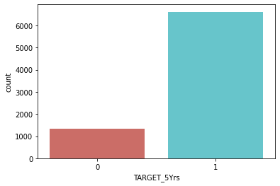

```python
# Display the counts of target value
sns.countplot(x='TARGET_5Yrs', data=data_cleaned, palette='hls')
plt.show()
```

```python
# Display the mean value of each variable for target 0 and 1
data_cleaned.groupby('TARGET_5Yrs').mean()
```

| TARGET_5Yrs | GP | MIN | PTS | FGM | FGA | FG% | FTM | FTA | FT% | OREB | DREB | REB | AST | STL | TOV |
| --- | --- | --- | --- | --- | --- | --- | --- | --- | --- | --- | --- | --- | --- | --- | --- |
| 0 | 53.535445 | 14.919231 | 5.499623 | 2.109125 | 4.923454 | 42.428658 | 1.028733 | 1.451131 | 70.321267 | 0.775641 | 1.645928 | 2.427753 | 1.328205 | 0.530543 | 1.012971 |
| 1 | 64.584757 | 19.261757 | 7.590957 | 2.937653 | 6.466702 | 45.077953 | 1.458854 | 2.045017 | 71.267685 | 1.141857 | 2.275019 | 3.414623 | 1.672221 | 0.670467 | 1.303917 |

According to the result above, the mean value of each feature is slightly higher when Target_5Yrs=1. This implies that each feature is very likely to have impact on the target value (1 or 0).

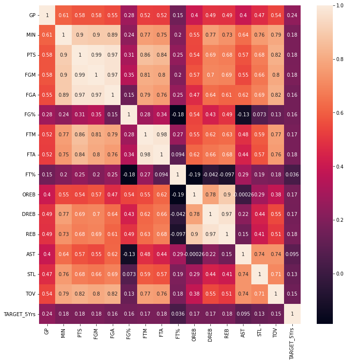

```python
# Plot the correlation matrix
matrix = data_cleaned.corr()
plt.figure(figsize = (12,12))
sns.heatmap(matrix,annot=True)
```

As shown in the correlation matrix plot, some features have the colinearity issue. For example, the features Points Per Game(PTS), Field Goals Made(FGM), Field Goals Attempts(FGA) are highly correlated at around 97%-99%. Similar case for (Free Throw Made) FTM and (Free Throw Made) FTA. This is understandable as the number of free throw made are most likely to be increased with more free throw attempts. Other features with high colinearity include (Offensive Rebounds)OREB, (Defensive Rebounds)DREB and (Rebounds)REB.

```python
# Extract the column 'TARGET_5Yrs' and save it into variable called target
target=data_cleaned.pop('TARGET_5Yrs')
```

```python
# Import StandardScaler from sklearn.preprocessing
from sklearn.preprocessing import StandardScaler
```

```python
# Instantiate the StandardScaler
scaler=StandardScaler()
```

```python
# Fit and apply the scaling on data_cleaned
data_cleaned=scaler.fit_transform(data_cleaned)
```

```python
# Import dump from joblib
from joblib import dump
```

```python
# Save the scaler into the folder models and call the file scaler.joblib
dump(scaler, '../models/scaler.joblib')
```

```
['../models/scaler.joblib']
```

```python
# Import train_test_split from sklearn.model_selection
from sklearn.model_selection import train_test_split
```

```python
#  Split the training data randomly with random_state=8 into 2 different sets: training (80%) and validation (20%)
X_train, X_val, y_train, y_val = train_test_split(data_cleaned, target, test_size=0.2, random_state=8)
```

```python
# Save the different sets in the folder `data/processed`
np.save('../data/processed/X_train',X_train)
np.save('../data/processed/X_val',X_val)
np.save('../data/processed/y_train',y_train)
np.save('../data/processed/y_val',y_val)
```

## Get baseline model

```python
# Find the mode of the target variable from the training set
y_mode=y_train.mode()
```

```python
# Create a numpy array called y_base of dimensions (len(y_train), 1) filled with the mode value
y_base=np.full((len(y_train),1),y_mode)
```

```python
# Import roc_au_score from sklearn.metrics
from sklearn.metrics import roc_auc_score
```

```python
# Print the roc_au_score for baseline model
roc_auc_score(y_train,y_base)
```

```
0.5
```